# The Dog That Did Not Bark: A Defense of Return Predictability (Replication)

## Table 1

Table 1 - Forecasting regressions

|  | $b$ | $t$ | $R^2(\%)$ | $\sigma(bx)(\%)$ |
| --- | --- | --- | --- | --- |
| **Regression** |  |  |  |  |
| $R_{t+1} = a + b(D_t / P_t ) + \epsilon_{t+1}$ | 3.01 | 2.33 | 5.7 | 4.8 |
| $R_{t+1} - R^f_t = a + b(D_t / P_t ) + \epsilon_{t+1}$ | 3.02 | 2.32 | 5.7 | 4.8 |
| $D_{t+1} / D_t = a + b(D_t / P_t ) + \epsilon_{t+1}$ | -1.12 | -1.54 | 2.6 | 1.8 |
| $r_{t+1} = a + b(d_t - p_t ) + \epsilon^r_{t+1}$ | 0.09 | 1.93 | 4.0 | 3.9 |
| $\Delta d_{t+1} = a + b(d_t - p_t ) + \epsilon^{dp}_{t+1}$ | -0.04 | -1.32 | 1.9 | 1.6 |

The result is quite similar to paper’s result. The coefficients of dividend growth and log dividend growth are negative as expected, as high dividend/price ratio implies low price, which indicates that the dividend in the future would be low.

## Table 2

Table 2 - Forecasting regressions and null hypothesis

|  | Estimates $\hat{b}, \hat{\phi}$ | Estimates $\sigma(\hat{b})$ | Estimates $implied$ | $\epsilon$ s.d. (diagonal) and correlation $r$ | $\epsilon$ s.d. (diagonal) and correlation $\Delta d$ | $\epsilon$ s.d. (diagonal) and correlation $dp$ | Null 1 $b, \phi$ | Null 2 $b, \phi$ |
| --- | --- | --- | --- | --- | --- | --- | --- | --- |
| $r$ | 0.089 | 0.046 | 0.056 | 19.0 | 11.2 | -67.8 | 0.0000 | 0.0000 |
| $\Delta d$ | -0.036 | 0.027 | -0.003 | 11.2 | 11.3 | 20.7 | -0.0925 | -0.0442 |
| $dp$ | 0.940 | 0.038 | 0.906 | -67.8 | 20.7 | 15.5 | 0.9399 | 0.9900 |

## Table 3

Table 3 - Percent probability values under the $\phi = 0.939$ null

|  | $b_r$ | $t_r$ | $b_d$ | $t_d$ |
| --- | --- | --- | --- | --- |
| Real | 17.1 | 8.4 | 2.8 | 6.1 |
| Excess | 16.7 | 9.5 | 3.5 | 7.2 |

The result is the probability that the simulated values are larger than the sample values. Number of iteration: 5000

## Figure 1 - Joint distribution of the coefficients ($b_r$ and $b_d$) and their t-statistics

Number of iteration: 5000. The round blue dot is the sample values, the diamond red dot is the null used to simulate data.

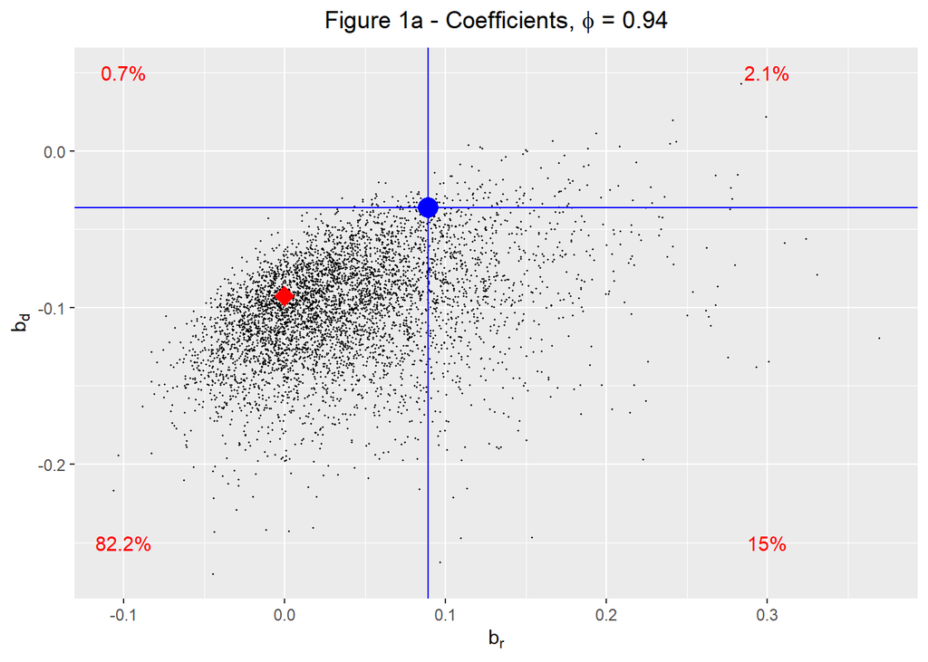

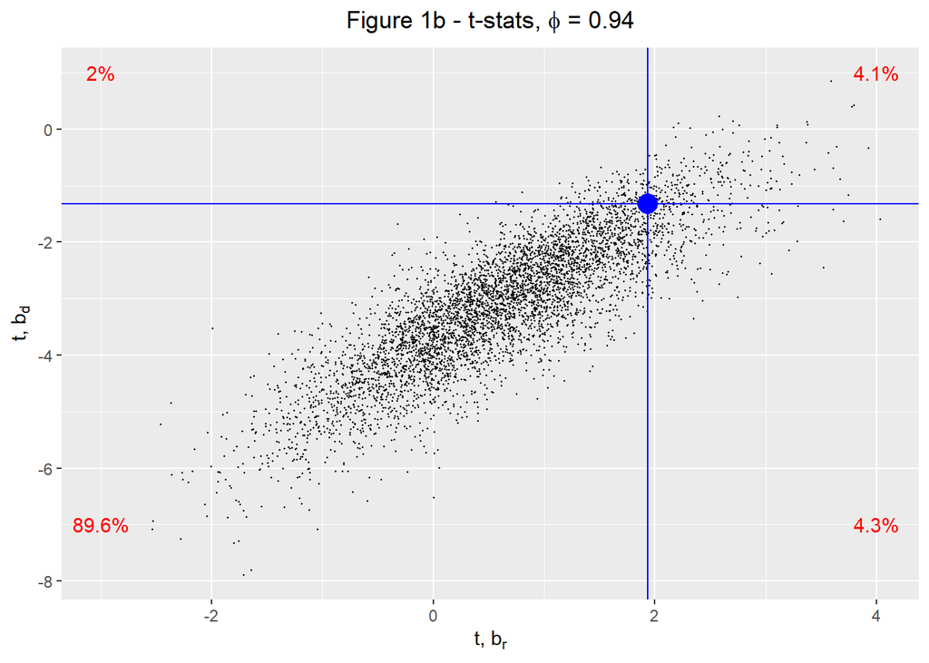

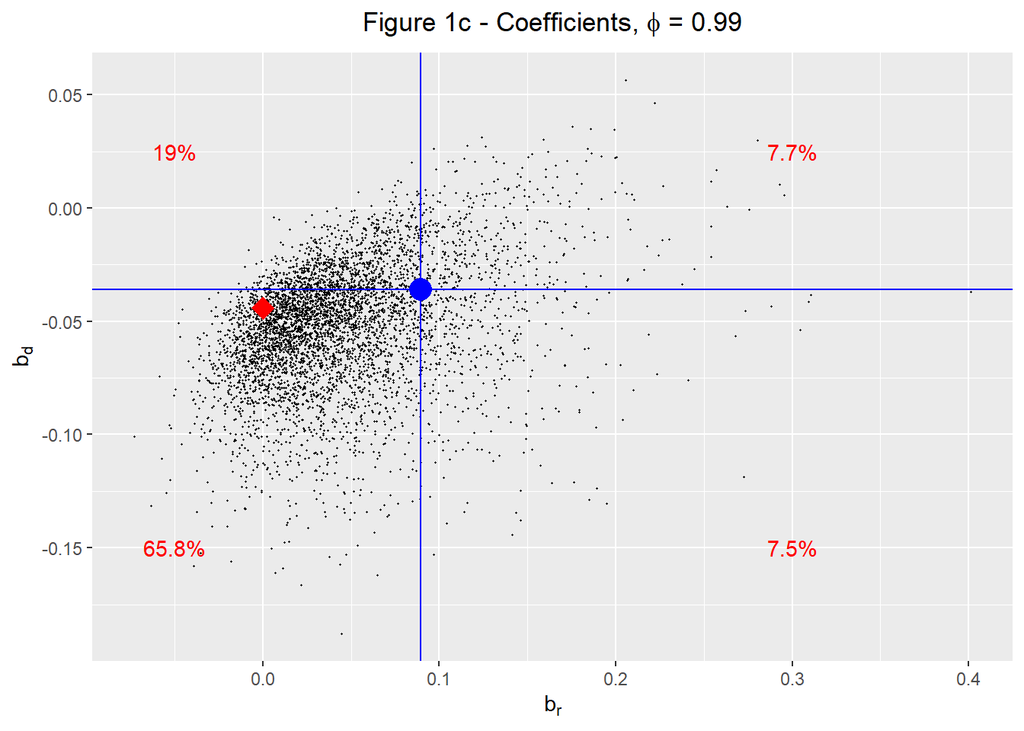

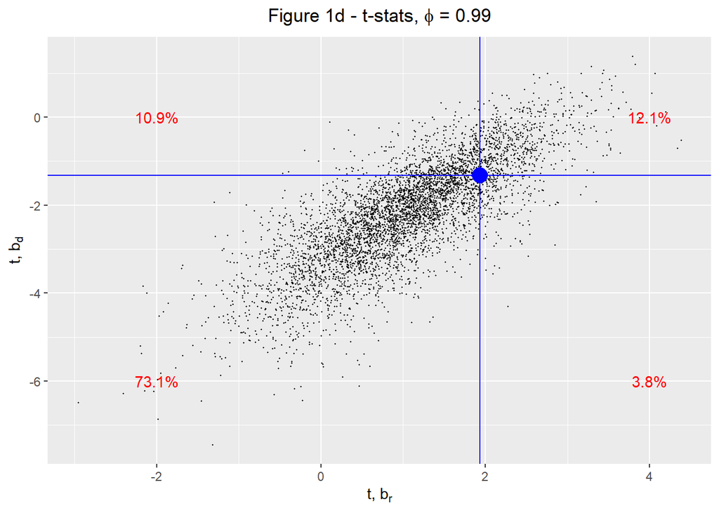

## Table 4

Table 4 - Long-run regression coefficients

[output not shown]

The p-values are retrieved from the simulation with known $b_r = 0$ and $\phi = 0.940$. I did not change the selection of the coefficients to reduce calculation time, so the p-value is not a range.

## Figure 2 - Distribution of the $b_r^{lr}$

Number of iteration: 5000. The vertical line is the sample value.

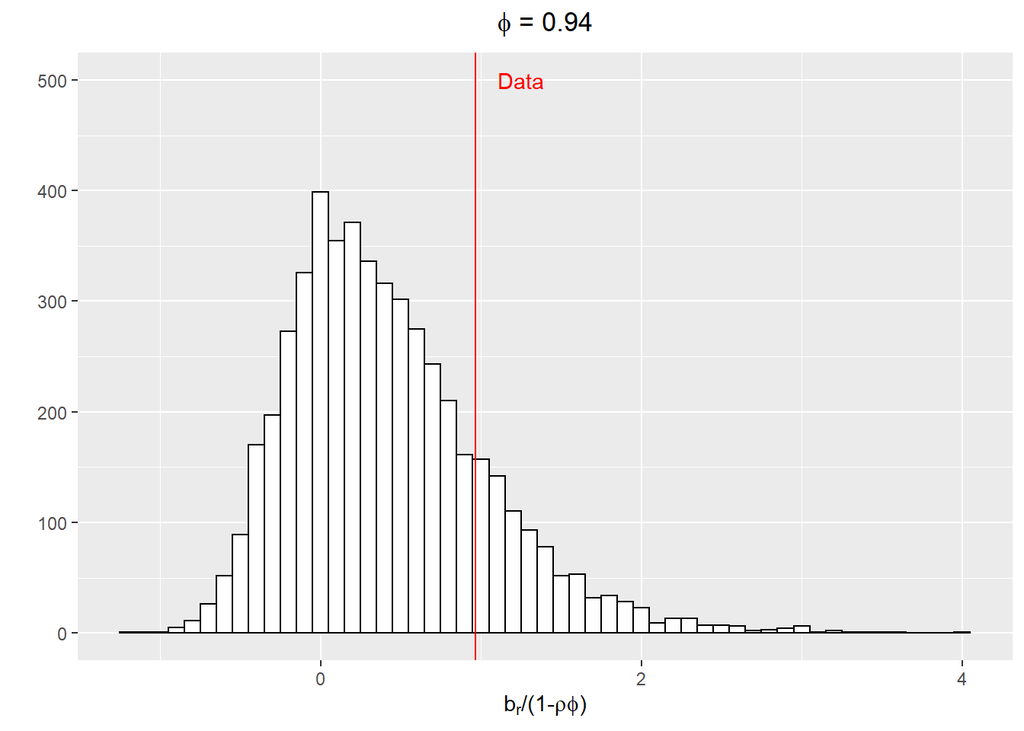

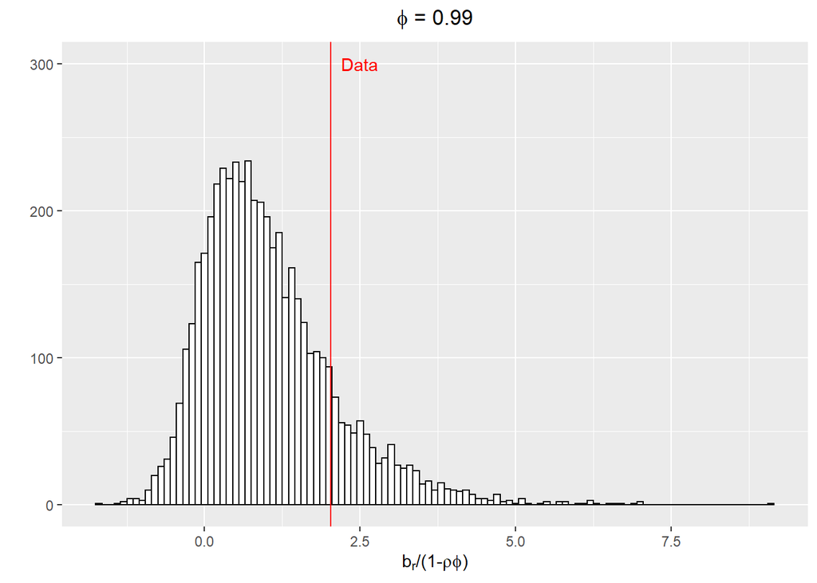

## Figure 3 - Joint distribution of $b_r$ and $\phi$

Number of iteration: 5000. The dashed line ($b_d$) is $b_r = 1- \rho\phi + \hat{b_d}$, the solid line $b_r^{lr}$ is $b_r/(1-\rho\phi) = \hat{b_r}/(1-\rho\hat{\phi})$.

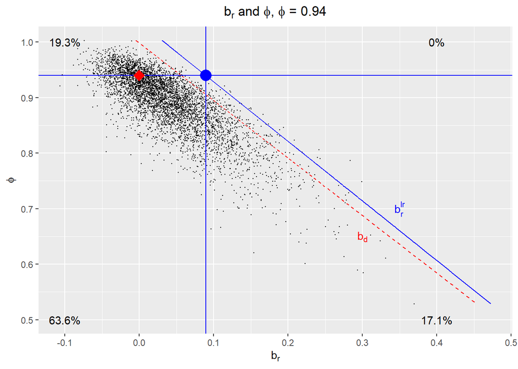

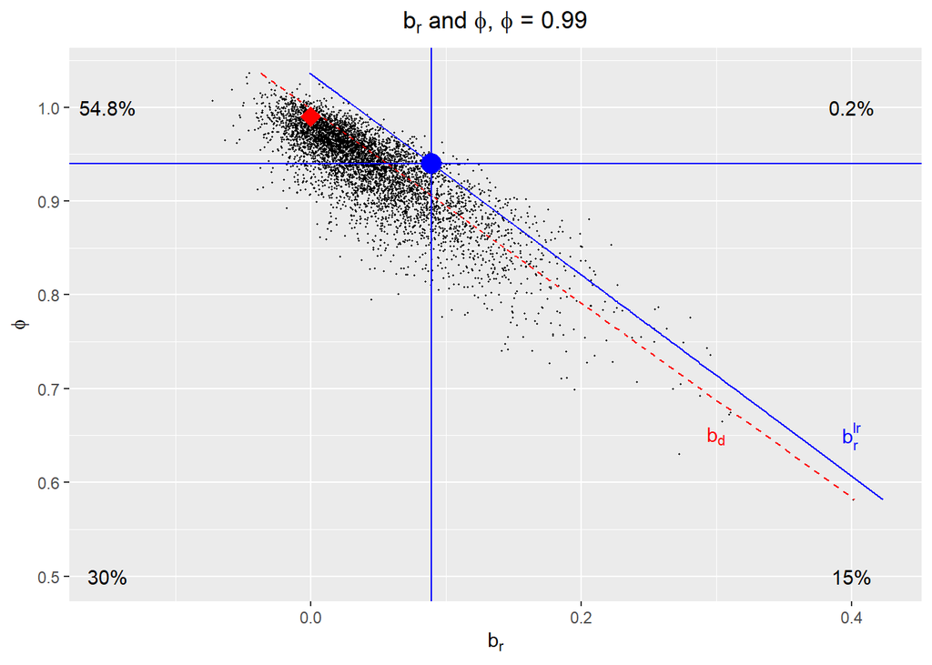

## Table 5

Table 5 - The effects of dividend-yield autocorrelation $\phi$

| Null $\phi$ | Percentage probability values Real returns $b_r$ | Percentage probability values Real returns $b_d$ | Percentage probability values Excess returns $b_r$ | Percentage probability values Excess returns $b_d$ | Other Statistics $\sigma (dp)$ | Other Statistics 1/2 life |
| --- | --- | --- | --- | --- | --- | --- |
| 0.90 | 18.2 | 0.4 | 18.9 | 0.8 | 0.36 | 6.6 |
| 0.94 | 17.1 | 2.8 | 16.7 | 3.5 | 0.45 | 11.2 |
| 0.96 | 15.4 | 7.4 | 15.5 | 7.4 | 0.55 | 17 |
| 0.98 | 15.6 | 16.9 | 15.2 | 19.1 | 0.78 | 34.3 |
| 0.99 | 15.2 | 26.7 | 15.7 | 29.1 | 1.1 | 69 |
| 1 | 15.7 | 40.3 | 14.6 | 44.4 | $\infty$ | $\infty$ |
| 1.01 | 13.8 | 62.3 | 13.4 | 65.6 | $\infty$ | $\infty$ |

The values in the table are the probability that the coefficients are larger than the sample values, with the number of iteration is 5000.

## Figure 5 - Joint distribution of $b_r$ and $\phi$ estimates, together with regions implied by long-run regressions

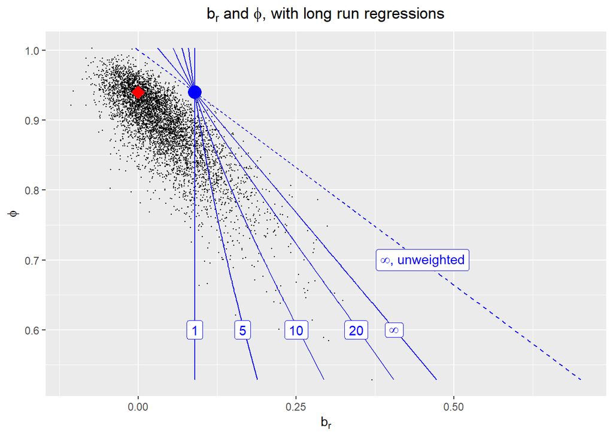

## Figure 6 - Distribution of the Goyal - Welch statistic

Number of iteration: 5000. The vertical line is the sample value.

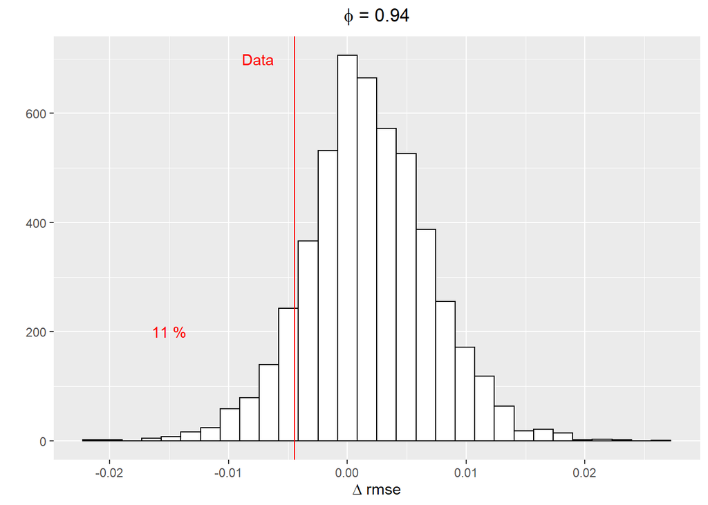

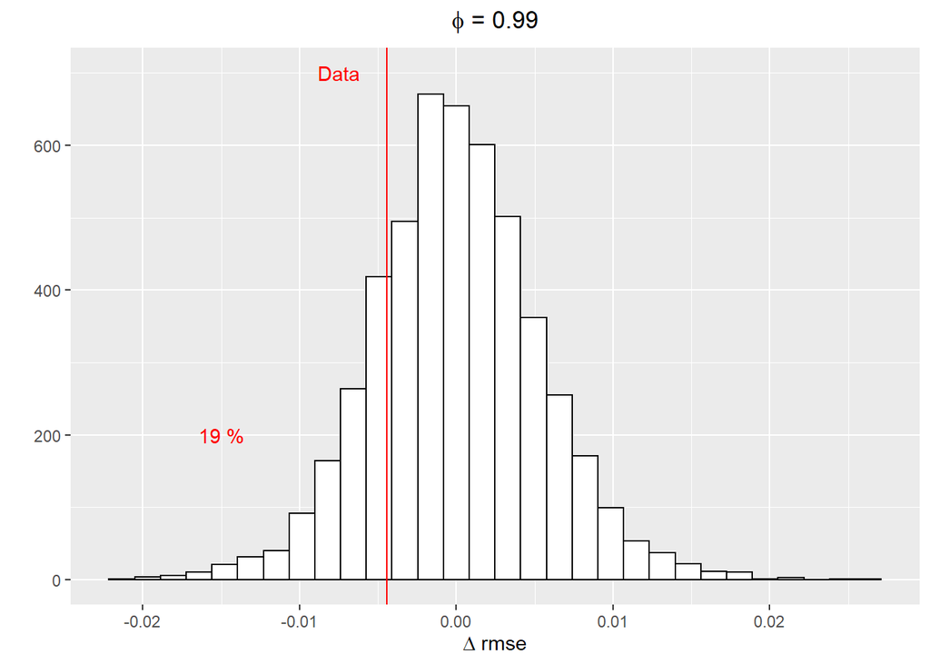